# Single Usability Metric for Accessibility (SUMA)

Vanessa Nasr

2024-07-19

## Finding SUMA

This is a document showing the process to find SUMA. First, the process to determine the final model dimensions is shown using **Principal Component Analysis (PCA)** in R-Studio. Next, the final model tool and its corresponding VBA code is provided here [SUMA Model.](https://github.com/vanessanasrtamu/SingleUsabilityMetricforAccessibility/blob/main/SUMA%20Model.xlsm)

## 1. Load data and libraries

```r
#Set working directory
setwd("C:/Users/vanes/Documents/A-Research/A_Indoor Navigation/A_Defense/PCA")

# Load libraries
library(ggplot2)
library(FactoMineR)
library(factoextra)
# Upload data
data <- read.csv('Final Data.csv')
```

## 2. Run PCA

Here PCA will be conducted.

```r
# Run Principal Component Analysis
data.pca <- prcomp(data, center = TRUE, scale = TRUE)
```

## 3. Interpret PCA- PC Selection

Now researcher judgement will be used to determine which principal components (PC) on 3 criteria.

**3.1. Visualization (Scree plot):** visualize the variability each PC accounts for. An elbow in the plot usually signifies around where you will define a cutoff for the PC to keep.

**3.2. Kaisers Rule:** Selected PC should have an eigenvalue greater than 1.

**3.3. Proportion of Variance:** Selected PC should account for at least 50% of the original dataset’s variability.

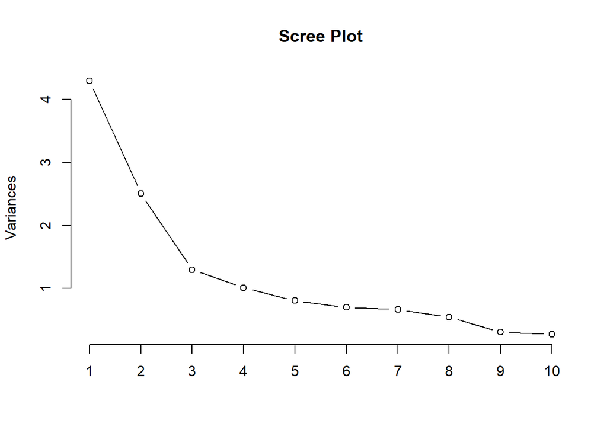

```r
# 3.1. Visualization )Scree plot)
plot(data.pca, type="l", main= "Scree Plot")
```

```r
# 3.2. Kaisers Rule
eigen(cor(data))$values
```

```
##  [1] 4.2892832 2.5078757 1.2962672 1.0134558 0.8086376 0.7008438 0.6659542
##  [8] 0.5464710 0.3083299 0.2727792 0.2424242 0.1861854 0.1614928
```

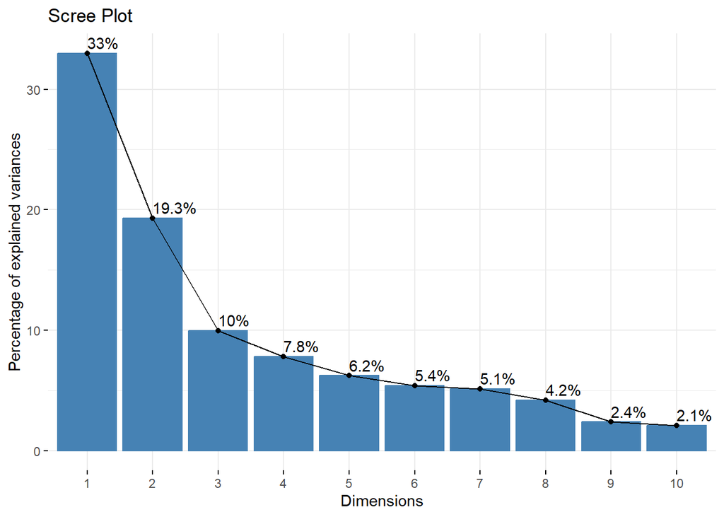

```r
# 3.3. Proportion of Variance
# Shown on Scree plot
fviz_eig(data.pca, addlabels = TRUE, main= "Scree Plot")
```

```r
# Proportion of variance of each PC and cumulative variance
summary(data.pca)
```

```
## Importance of components:
##                           PC1    PC2     PC3     PC4    PC5     PC6     PC7
## Standard deviation     2.0711 1.5836 1.13854 1.00671 0.8992 0.83716 0.81606
## Proportion of Variance 0.3299 0.1929 0.09971 0.07796 0.0622 0.05391 0.05123
## Cumulative Proportion  0.3299 0.5229 0.62257 0.70053 0.7627 0.81664 0.86787
##                            PC8     PC9    PC10    PC11    PC12    PC13
## Standard deviation     0.73924 0.55527 0.52228 0.49237 0.43149 0.40186
## Proportion of Variance 0.04204 0.02372 0.02098 0.01865 0.01432 0.01242
## Cumulative Proportion  0.90991 0.93362 0.95461 0.97326 0.98758 1.00000
```

```r
# Rotation matrix:
print(data.pca$rotation)
```

```
##                               PC1         PC2         PC3         PC4
## Satisfaction           0.40743266 -0.12412628  0.06300737  0.29007977
## Percievable            0.36098097 -0.26082404  0.14168258 -0.10163382
## Operable               0.38014743 -0.12562730 -0.01195847  0.38912573
## Understandable         0.37523835 -0.24409040  0.05821591  0.29383288
## Robust                 0.25146943 -0.22280222  0.16742767 -0.58055299
## Flexibility            0.21368316 -0.28899384  0.08706650 -0.47325845
## Recall                 0.10238364  0.33937353  0.31576946  0.11403152
## recognition            0.06860482  0.26417873  0.44885222 -0.09502660
## Errors                -0.27243654 -0.06886467  0.46023554 -0.03258493
## Hints                 -0.25365329 -0.40140601 -0.11531735  0.07042785
## Trials.before.mastery -0.29259051 -0.33528459  0.38199373  0.15701651
## Times                 -0.20221902 -0.40896128 -0.30222492  0.01551537
## Task.Completetion      0.17095517  0.27846701 -0.41624368 -0.23195333
##                                 PC5         PC6         PC7          PC8
## Satisfaction          -6.382866e-02 -0.05814290 -0.09134504  0.072806791
## Percievable            8.474734e-02 -0.02164993 -0.07684818 -0.251118586
## Operable               7.432292e-02  0.01846792 -0.10258219  0.080594815
## Understandable        -1.066560e-02 -0.09391828 -0.11173894 -0.005618854
## Robust                 9.489796e-02  0.03438693  0.06356460 -0.543170525
## Flexibility           -1.373159e-01 -0.13897093  0.19361905  0.743381432
## Recall                -2.697261e-01 -0.65794657  0.46444916 -0.163706438
## recognition           -6.465558e-01  0.31189661 -0.43409357  0.021846042
## Errors                 4.106476e-01 -0.35960673 -0.40590319  0.145051827
## Hints                 -3.988881e-01 -0.19030383 -0.01236963 -0.110976421
## Trials.before.mastery  5.044985e-02 -0.07309710 -0.11270007 -0.055735673
## Times                 -3.662921e-01 -0.19941005 -0.10840659 -0.115893315
## Task.Completetion     -7.256901e-06 -0.47505822 -0.57245000 -0.017052466
##                               PC9        PC10        PC11         PC12
## Satisfaction           0.40997585 -0.00543586 -0.25967070  0.060965255
## Percievable           -0.57546260 -0.02427120 -0.59321972 -0.061999832
## Operable              -0.39176333 -0.30531505  0.61191582 -0.202542533
## Understandable         0.34065065  0.29658156  0.03569358  0.286392537
## Robust                 0.23978526 -0.03935357  0.37399904  0.031202287
## Flexibility           -0.01759915  0.01483129  0.03522686 -0.090279321
## Recall                -0.03608573 -0.08474132  0.01408464 -0.050235540
## recognition           -0.03559159 -0.06469405  0.03440940  0.030287365
## Errors                -0.05410484 -0.20772107  0.05049328  0.412992545
## Hints                 -0.32403870  0.49473219  0.20677412  0.292142287
## Trials.before.mastery  0.17408134  0.21393257 -0.01381877 -0.727797627
## Times                  0.18031804 -0.65658662 -0.12677012 -0.004317853
## Task.Completetion      0.01087488  0.20071686  0.02968442 -0.266856207
##                                PC13
## Satisfaction          -0.6856531697
## Percievable            0.0845177160
## Operable              -0.0556780714
## Understandable         0.6333556968
## Robust                -0.1135394154
## Flexibility            0.0327733631
## Recall                 0.0475995496
## recognition            0.0567698389
## Errors                -0.0722757522
## Hints                 -0.2657354623
## Trials.before.mastery  0.0418771774
## Times                  0.1464584515
## Task.Completetion     -0.0005291889
```

Using the criteria it was decided to keep the first 2 PC based on:

1. Visualization- the scree plot apprears to level off after PC 2
2. Kaisers Rule- can select up to the first 4 PC since they have an eigenvalue above 1
3. Proportion of Variance- should select at least the first 2 PC to account for more than 50% of the cumulative variance

## 4. Reduced Dimension Selection

Now that the first 2 PC were determine to keep, which original dataset dimensions to keep will be selected. In behavioral research loadings from 0.32 to 0.50 are used as selection thresholds.

```r
# Print the loadings for the first two principal components
rotation_matrix <- data.pca$rotation
print(rotation_matrix[, 1:2])
```

```
##                               PC1         PC2
## Satisfaction           0.40743266 -0.12412628
## Percievable            0.36098097 -0.26082404
## Operable               0.38014743 -0.12562730
## Understandable         0.37523835 -0.24409040
## Robust                 0.25146943 -0.22280222
## Flexibility            0.21368316 -0.28899384
## Recall                 0.10238364  0.33937353
## recognition            0.06860482  0.26417873
## Errors                -0.27243654 -0.06886467
## Hints                 -0.25365329 -0.40140601
## Trials.before.mastery -0.29259051 -0.33528459
## Times                 -0.20221902 -0.40896128
## Task.Completetion      0.17095517  0.27846701
```

## 5. PCA proof

Last proofs can be checked to ensure fundamental assumptions and properties of PCA are upheld.

**5.1. Eigenvalues of Correlation Matrix= Variance of Transformed Data** If the data has been standardized (mean-centered and scaled to unit variance), the correlation matrix and the covariance matrix of the original data are essentially the same when eigenvalues are considered

**5.2. Proof of Orthogonality** The diagonal matrix with 1s on the diagonal and 0s elsewhere in the correlation matrix of proved orthogonality and standardization.

```r
# PCA Proof
# 5.1. Need PC to have mean=0, and variance=eigenvalue
eigen(cor(data))$values
```

```
##  [1] 4.2892832 2.5078757 1.2962672 1.0134558 0.8086376 0.7008438 0.6659542
##  [8] 0.5464710 0.3083299 0.2727792 0.2424242 0.1861854 0.1614928
```

```r
diag(var(data.pca$x[,]))
```

```
##       PC1       PC2       PC3       PC4       PC5       PC6       PC7       PC8
## 4.2892832 2.5078757 1.2962672 1.0134558 0.8086376 0.7008438 0.6659542 0.5464710
##       PC9      PC10      PC11      PC12      PC13
## 0.3083299 0.2727792 0.2424242 0.1861854 0.1614928
```

```r
# 5.2. Show PC are orthogonal
cor(data.pca$x)
```

```
##                PC1           PC2           PC3           PC4           PC5
## PC1   1.000000e+00  6.025343e-20 -1.224612e-16  2.204008e-16  9.997869e-17
## PC2   6.025343e-20  1.000000e+00 -2.273681e-17 -3.381308e-16 -2.954093e-16
## PC3  -1.224612e-16 -2.273681e-17  1.000000e+00 -3.601802e-16 -1.148432e-17
## PC4   2.204008e-16 -3.381308e-16 -3.601802e-16  1.000000e+00 -1.072004e-16
## PC5   9.997869e-17 -2.954093e-16 -1.148432e-17 -1.072004e-16  1.000000e+00
## PC6  -2.447470e-16 -1.052046e-16 -1.304982e-16  2.173398e-16  4.213683e-17
## PC7  -4.989024e-16  2.074557e-16  1.461877e-16  7.784022e-17 -4.929628e-16
## PC8   2.706046e-16  1.207084e-17  3.432536e-16  9.348395e-16  1.952246e-16
## PC9  -1.472830e-15 -1.673737e-17  1.211626e-16 -3.573365e-17  4.965619e-16
## PC10 -1.240592e-15  6.787356e-17 -1.430841e-16 -2.520490e-16 -1.203846e-16
## PC11  9.393499e-16 -4.722369e-16  4.435577e-16  1.696966e-16 -9.196416e-17
## PC12  9.844457e-17 -1.484719e-16 -5.418184e-16 -9.149781e-16 -7.012350e-16
## PC13  9.087503e-17  2.374371e-16 -2.939414e-16 -5.938340e-16  1.063313e-16
##                PC6           PC7           PC8           PC9          PC10
## PC1  -2.447470e-16 -4.989024e-16  2.706046e-16 -1.472830e-15 -1.240592e-15
## PC2  -1.052046e-16  2.074557e-16  1.207084e-17 -1.673737e-17  6.787356e-17
## PC3  -1.304982e-16  1.461877e-16  3.432536e-16  1.211626e-16 -1.430841e-16
## PC4   2.173398e-16  7.784022e-17  9.348395e-16 -3.573365e-17 -2.520490e-16
## PC5   4.213683e-17 -4.929628e-16  1.952246e-16  4.965619e-16 -1.203846e-16
## PC6   1.000000e+00 -1.565405e-16 -4.889407e-16  4.550821e-16 -1.318238e-16
## PC7  -1.565405e-16  1.000000e+00 -1.162650e-16  3.349880e-17 -2.330568e-16
## PC8  -4.889407e-16 -1.162650e-16  1.000000e+00 -8.573692e-16 -2.751941e-16
## PC9   4.550821e-16  3.349880e-17 -8.573692e-16  1.000000e+00 -2.644992e-16
## PC10 -1.318238e-16 -2.330568e-16 -2.751941e-16 -2.644992e-16  1.000000e+00
## PC11  1.598627e-16 -1.787284e-16 -3.556507e-16 -4.862962e-16 -6.681759e-17
## PC12  2.814743e-16 -3.878900e-16 -1.494996e-16 -5.800430e-16  9.684632e-17
## PC13  5.764499e-16  6.344024e-16 -1.008947e-15  4.340642e-16  5.482013e-16
##               PC11          PC12          PC13
## PC1   9.393499e-16  9.844457e-17  9.087503e-17
## PC2  -4.722369e-16 -1.484719e-16  2.374371e-16
## PC3   4.435577e-16 -5.418184e-16 -2.939414e-16
## PC4   1.696966e-16 -9.149781e-16 -5.938340e-16
## PC5  -9.196416e-17 -7.012350e-16  1.063313e-16
## PC6   1.598627e-16  2.814743e-16  5.764499e-16
## PC7  -1.787284e-16 -3.878900e-16  6.344024e-16
## PC8  -3.556507e-16 -1.494996e-16 -1.008947e-15
## PC9  -4.862962e-16 -5.800430e-16  4.340642e-16
## PC10 -6.681759e-17  9.684632e-17  5.482013e-16
## PC11  1.000000e+00 -4.661230e-16 -7.923753e-16
## PC12 -4.661230e-16  1.000000e+00 -1.311666e-17
## PC13 -7.923753e-16 -1.311666e-17  1.000000e+00
```